# 통계밥법론 Chapter10 실습코드

202140191 엄태훈

2021-06-05(SAT)

# Chap10 Multiple Regression - Dummy Variables,Contrasts,and Analysis of Covariacne

이번 챕터에서는 앞서 살펴본 다중회귀분석과 더불어 **더미 변수**와 **대조**에 대해 알아보도록 한다.

**더미 변수(Dummy variable)**은 질적인 특성을 갖고있는 독립변수들을 통합하는 것을 말한다. 예를 들어, A,B,C 3개의 변수를 가지고 있다고 가정하고 이에 대한 더미 변수화를 지정하게 되면, A =(1,0,0), B=(0,1,0), C=(0,0,1)와 같은 식으로 표현될 수 있다.

또한, 분산분석의 개념과 회귀분석의 개념이 혼합된 **공분산분석(Analysiss of Covariance)**에 대해서도 알아보자.

## 10.2 Example-Height and Weight

### 10.2.2 Data Description

- feet: 정수로 반올림한 피트 단위의 높이
- inches: 인치단위의 높이
- months: 월 단위로 표혀한 나이
- lbs: 파운드 단위의 몸무게
- sex: 남성 혹은 여성
- meters: 미터단위의 높이

### 10.2.3 Data Problems

```r
library(HH)
data(htwt)

levels(factor(htwt$sex,exclude=NULL))
```

```
## [1] "f" "m" NA
```

```r
any(is.na(htwt$ht))
```

```
## [1] TRUE
```

`any`함수를 이용해 *ht*변수 안에 결측값이 있는지 확인한다.  
확인결과, TRUE를 반환하여 결측값이 있는 것으로 보인다.

```r
for (h in tapply(htwt$ht,factor(htwt$sex,exclude = NULL),c)){
  stem(h,scal=1.5)
}
```

```
##
##   The decimal point is at the |
##
##   58 | 0
##   60 |
##   62 | 00000
##   64 | 000000000
##   66 | 000008
##   68 | 0
##
##
##   The decimal point is at the |
##
##   62 | 0
##   64 | 0
##   66 | 000
##   68 | 00
##   70 |
##   72 | 000000
##   74 | 00
```

*ht*변수를 성별에 따라 `stem`함수를 이용하여 줄기 잎 그림 으로 표현하였다.

[figure not shown]

```r
library(dplyr)
df_htwt <- htwt %>%
  select("lbs","months","sex","ht")

splom(~df_htwt,groups=df_htwt$sex,pch=c(17,19),col=c("#7685c8","#E16A92"),key=list(text=list(c("Male","Female")),
      points=list(pch=c(17,19),col=c("#7685C8","#E16A92"))))
```

데이터 탐색을 위해 성별을 그룹으로 지정하고 `splom`함수를 사용하여 산점도 행렬을 그린 후, 변수 간 관계를 살펴보았다.

[figure not shown]

```r
xyplot(lbs~ht,data=htwt,groups=sex,pch=c(17,19),
       col=c("#7685c8","#E16A92"),
       key=list(text=list(c("Male","Female")),
                points=list(pch=c(17,19),
                            col=c("#7685C8","#E16A92"))))
```

성별에 따른 ht변수와 lbs변수의 산점도를 그려보았다.

```r
## one-wway analysis of variance
htwt.aov <- aov(ht ~ sex,data=htwt)

summary(htwt.aov)
```

```
##             Df Sum Sq Mean Sq F value   Pr(>F)
## sex          1  237.2   237.2   26.66 9.78e-06 ***
## Residuals   35  311.3     8.9
## ---
## Signif. codes:  0 '***' 0.001 '**' 0.01 '*' 0.05 '.' 0.1 ' ' 1
## 2 observations deleted due to missingness
```

```r
model.tables(htwt.aov,type="means")
```

```
## Tables of means
## Grand mean
##
## 66.53378
##
##  sex
##         f    m
##     64.44 69.6
## rep 22.00 15.0
```

ht변수에 대해서 성별로 평균 차이가 있는지에 대한 분산분석을 진행한 결과, P-value는 0에 매우 가까운 값으로 유의수준 0.05보다 작으므로 유의한 것을 확이할 수 있다.

따라서, 성별에 따라서 ht변수에 대한 평균차이가 존재하는 것을 알 수 있다.

### 10.2.4 Three Variants on the Analysis

```r
## dummy variable

htwt$female <- as.numeric(htwt$sex == "f")
```

성별이 female인 경우를 1로 지정하고 남성인 경우를 0으로 지정하여 더미변수화를 진행해주었다.

```r
htwt.lm <- lm(ht ~ female, data=htwt)

summary(htwt.lm)
```

```
##
## Call:
## lm(formula = ht ~ female, data = htwt)
##
## Residuals:
##     Min      1Q  Median      3Q     Max
## -7.6000 -2.4432  0.5568  2.4000  5.4000
##
## Coefficients:
##             Estimate Std. Error t value Pr(>|t|)
## (Intercept)  69.6000     0.7701  90.380  < 2e-16 ***
## female       -5.1568     0.9987  -5.164 9.78e-06 ***
## ---
## Signif. codes:  0 '***' 0.001 '**' 0.01 '*' 0.05 '.' 0.1 ' ' 1
##
## Residual standard error: 2.983 on 35 degrees of freedom
##   (2 observations deleted due to missingness)
## Multiple R-squared:  0.4324, Adjusted R-squared:  0.4162
## F-statistic: 26.66 on 1 and 35 DF,  p-value: 9.78e-06
```

```r
anova(htwt.lm)
```

```
## Analysis of Variance Table
##
## Response: ht
##           Df Sum Sq Mean Sq F value   Pr(>F)
## female     1 237.18 237.179  26.663 9.78e-06 ***
## Residuals 35 311.34   8.895
## ---
## Signif. codes:  0 '***' 0.001 '**' 0.01 '*' 0.05 '.' 0.1 ' ' 1
```

더미변수화를 진행한 후 회귀분석과 다시 한 번 분산분석을 진행해본 결과, 유의한 변수임을 알 수 있었고 분산분석의 결과는 앞선 결과와 동일하게 성별 간 평균차이가 존재하는 것을 확인할 수 있었다.

```r
## dummy variable

htwt$treat <- (htwt$sex == "f") - (htwt$sex == "m")

htwtb.lm <- lm(ht ~ treat,data=htwt)

summary(htwtb.lm)
```

```
##
## Call:
## lm(formula = ht ~ treat, data = htwt)
##
## Residuals:
##     Min      1Q  Median      3Q     Max
## -7.6000 -2.4432  0.5568  2.4000  5.4000
##
## Coefficients:
##             Estimate Std. Error t value Pr(>|t|)
## (Intercept)  67.0216     0.4993 134.220  < 2e-16 ***
## treat        -2.5784     0.4993  -5.164 9.78e-06 ***
## ---
## Signif. codes:  0 '***' 0.001 '**' 0.01 '*' 0.05 '.' 0.1 ' ' 1
##
## Residual standard error: 2.983 on 35 degrees of freedom
##   (2 observations deleted due to missingness)
## Multiple R-squared:  0.4324, Adjusted R-squared:  0.4162
## F-statistic: 26.66 on 1 and 35 DF,  p-value: 9.78e-06
```

```r
anova(htwtb.lm)
```

```
## Analysis of Variance Table
##
## Response: ht
##           Df Sum Sq Mean Sq F value   Pr(>F)
## treat      1 237.18 237.179  26.663 9.78e-06 ***
## Residuals 35 311.34   8.895
## ---
## Signif. codes:  0 '***' 0.001 '**' 0.01 '*' 0.05 '.' 0.1 ' ' 1
```

앞선 더미변수 방법과는 다르게 여성일 경우 1, 남성일 경우 -1로 변환해 준 후, 다시 한 번 분석을 진행해본 결과 동일한 결과가 나온 것을 확인할 수 있다.

## 10.4 Polynomial Contrasts and Orthogonal Polynomials

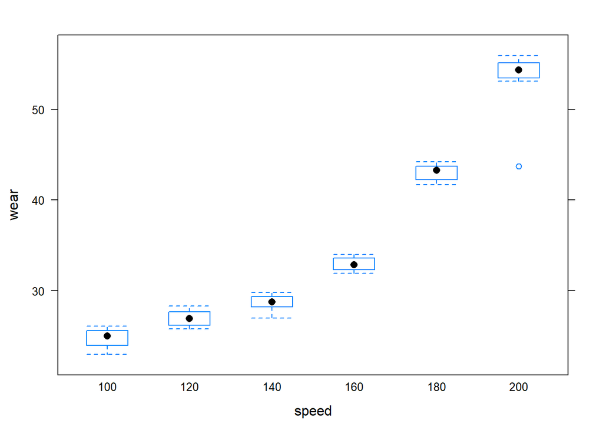

```r
data(fabricwear)

bwplot(wear~speed,data=fabricwear,ylab="wear",xlab="speed")
```

**fabricwear**데이터의 *wear,speed*변수를 이용하여 boxplot을 그려본 결과, speed가 높아짐에 따라 wear의 평균 또한 같이 높아지는 것을 확인할 수 있다.

```r
fabricwear.aov <- aov(wear ~ speed, data=fabricwear)

summary(fabricwear.aov)
```

```
##             Df Sum Sq Mean Sq F value Pr(>F)
## speed        5   4872   974.4   297.7 <2e-16 ***
## Residuals   42    137     3.3
## ---
## Signif. codes:  0 '***' 0.001 '**' 0.01 '*' 0.05 '.' 0.1 ' ' 1
```

분산분석 결과, 탐색적 자료분석을 통해 얻은 결과와 동일하게 wear변수에 대하여 적어도 한 speed 집단 간 유의한 평균차이가 발생하는 것을 알 수 있다.

```r
tmp.c <- zapsmall(contrasts(fabricwear$speed),14)

dimnames(tmp.c)[[1]] <- levels(fabricwear$speed)

tmp.c
```

```
##             .L         .Q         .C         ^4          ^5
## 100 -0.5976143  0.5455447 -0.3726780  0.1889822 -0.06299408
## 120 -0.3585686 -0.1091089  0.5217492 -0.5669467  0.31497039
## 140 -0.1195229 -0.4364358  0.2981424  0.3779645 -0.62994079
## 160  0.1195229 -0.4364358 -0.2981424  0.3779645  0.62994079
## 180  0.3585686 -0.1091089 -0.5217492 -0.5669467 -0.31497039
## 200  0.5976143  0.5455447  0.3726780  0.1889822  0.06299408
```

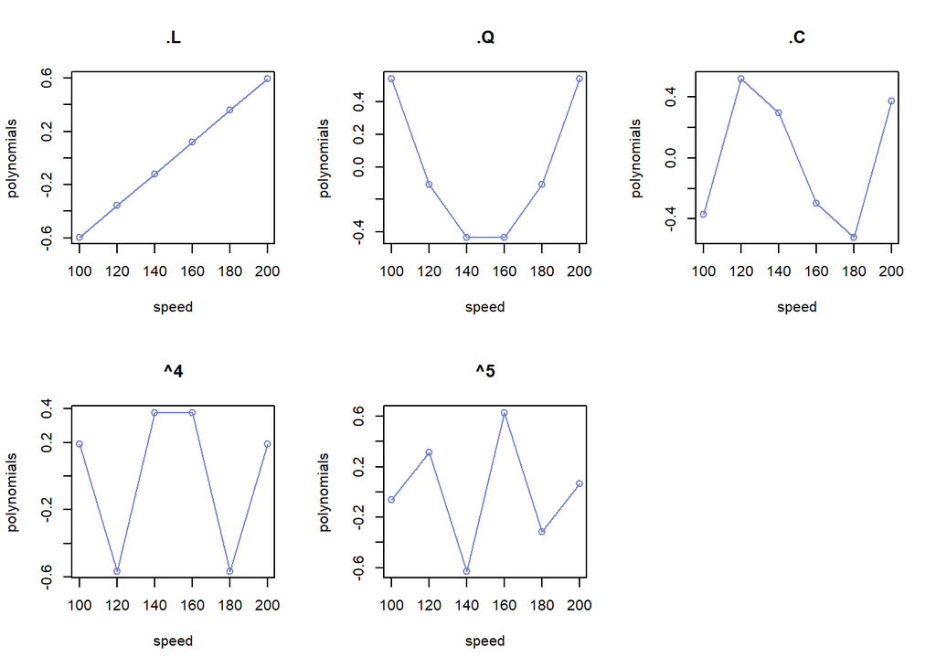

```r
par(mfrow=c(2,3))
tmp.c_df <- data.frame(tmp.c)
plot(rownames(tmp.c_df),tmp.c_df$.L,type="o",xlab="speed",ylab="polynomials",main=".L",col="#7685c8")
plot(rownames(tmp.c_df),tmp.c_df$.Q,type="o",xlab="speed",ylab="polynomials",main=".Q",col="#7685c8")
plot(rownames(tmp.c_df),tmp.c_df$.C,type="o",xlab="speed",ylab="polynomials",main=".C",col="#7685c8")
plot(rownames(tmp.c_df),tmp.c_df$X.4,type="o",xlab="speed",ylab="polynomials",main="^4",col="#7685c8")
plot(rownames(tmp.c_df),tmp.c_df$X.5,type="o",xlab="speed",ylab="polynomials",main="^5",col="#7685c8")
```

데이터를 1차,2차,3차,4차,5차로 변환시키고 차수가 증가함에 따른 변화를 살펴보기 위해 plot을 통해 나타내보았다.

```r
zapsmall(crossprod(tmp.c),13)
```

```
##    .L .Q .C ^4 ^5
## .L  1  0  0  0  0
## .Q  0  1  0  0  0
## .C  0  0  1  0  0
## ^4  0  0  0  1  0
## ^5  0  0  0  0  1
```

```r
min.nonzero <- function(x, digits=13){
  xx <- zapsmall(x,digits)
  min(xx[xx != 0])
}

tmp.min <- apply(abs(tmp.c),2,min.nonzero)

sweep(tmp.c,2,tmp.min, "/")
```

```
##     .L .Q    .C ^4  ^5
## 100 -5  5 -1.25  1  -1
## 120 -3 -1  1.75 -3   5
## 140 -1 -4  1.00  2 -10
## 160  1 -4 -1.00  2  10
## 180  3 -1 -1.75 -3  -5
## 200  5  5  1.25  1   1
```

```r
summary(fabricwear.aov,
        split=list(speed=list(speed.L=1,speed.Q=2,
                   speed.C=3,rest=4:5)))
```

```
##                  Df Sum Sq Mean Sq  F value   Pr(>F)
## speed             5   4872     974  297.705  < 2e-16 ***
##   speed: speed.L  1   4327    4327 1321.903  < 2e-16 ***
##   speed: speed.Q  1    513     513  156.760 9.12e-16 ***
##   speed: speed.C  1      7       7    2.105   0.1543
##   speed: rest     2     25      13    3.878   0.0285 *
## Residuals        42    137       3
## ---
## Signif. codes:  0 '***' 0.001 '**' 0.01 '*' 0.05 '.' 0.1 ' ' 1
```

```r
summary.lm(fabricwear.aov)
```

```
##
## Call:
## aov(formula = wear ~ speed, data = fabricwear)
##
## Residuals:
##     Min      1Q  Median      3Q     Max
## -9.4875 -0.6531  0.1813  0.8250  2.7125
##
## Coefficients:
##             Estimate Std. Error t value Pr(>|t|)
## (Intercept)  34.9292     0.2611 133.760  < 2e-16 ***
## speed.L      23.2562     0.6396  36.358  < 2e-16 ***
## speed.Q       8.0086     0.6396  12.520 9.12e-16 ***
## speed.C       0.9280     0.6396   1.451   0.1543
## speed^4      -1.6772     0.6396  -2.622   0.0121 *
## speed^5      -0.6000     0.6396  -0.938   0.3536
## ---
## Signif. codes:  0 '***' 0.001 '**' 0.01 '*' 0.05 '.' 0.1 ' ' 1
##
## Residual standard error: 1.809 on 42 degrees of freedom
## Multiple R-squared:  0.9726, Adjusted R-squared:  0.9693
## F-statistic: 297.7 on 5 and 42 DF,  p-value: < 2.2e-16
```

앞서, 차수 변환을 시켜준 데이터에 대하여 분산분석을 진행해 보았다.  
분산분석결과, 1차,2차,4차의 다항식은 유의한 평균차이가 적어도 한 집단 이상 존재한다는 결과를 얻을 수 있었다.  
3차,5차의 다항식은 P-value가 유의수준 0.05보다 높으므로 집단 간 유의한 평균차이가 존재하지 않는다.

## 10.6 Example-Hot Dog Data

### 10.6.2 Data Description

- Type: 핫도그의 유형
- Calories: 핫도그의 칼로리
- Sodium: 핫도그 당 나트륨 밀리그램

### 10.6.4 Concomitant Explanatory Variable _ ANCOVA

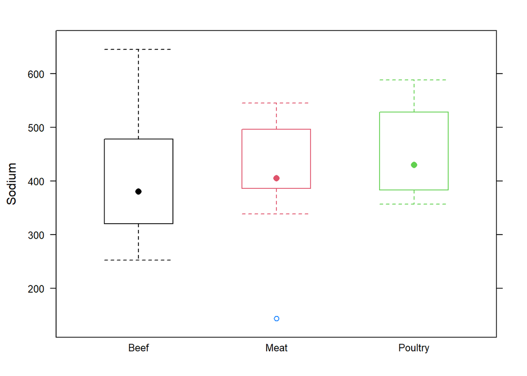

```r
data(hotdog)
bwplot(Sodium~Type,data=hotdog,col=c(1:3),
       par.settings=list(box.rectangle=list(col=c(1:3)),box.umbrella=list(col=c(1:3)),box.dot=list(col=c(1:3))))
```

탐색적 자료분석을 위한 boxplot 결과, 핫도그에 들어가느 고기 종류에 따른 나트륨은 큰 평균차이가 존재하지 않는 것 처럼 보인다.

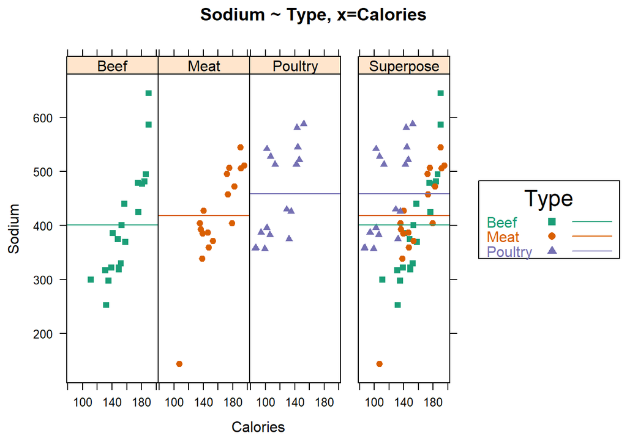

```r
data("col3x2")

hotdog.key <- list(title="Type", border=TRUE, space="right",
                   text=list(levels(hotdog$Type),
                             col=col3x2[1:3]),
                   points=list(pch=15:17,
                               col=col3x2[1:3]),
                   lines=list(lty=1,
                              lwd=trellis.par.get("superpose.line")$lwd[1:3],
                              col=col3x2[1:3]))
TxC <- ancovaplot(Sodium ~ Type, x=Calories, data=hotdog, col=col3x2,
                  main="Sodium ~ Type, x=Calories",
                  scales=list(alternating=FALSE),
                  between=list(x=c(0,0,1)))
update(TxC, key=hotdog.key)
```

핫도그의 고기 유형에 따른 나트륨을 비교하고 칼로리를 공변량으로 지정한 결과를 `ancovaplot`을 통해 살펴보았다.

그림으로만 확인해봤을때, 평균차이는 존재하지 않는 것처럼 보인다.

```r
aovStatementAndAnova(TxC)
```

```
## > anova(aov(Sodium ~ Type, data = hotdog))
```

```
## Analysis of Variance Table
##
## Response: Sodium
##           Df Sum Sq Mean Sq F value Pr(>F)
## Type       2  31739 15869.4  1.7778 0.1793
## Residuals 51 455249  8926.4
```

```r
anova(aov(Sodium~Type,data=hotdog))
```

```
## Analysis of Variance Table
##
## Response: Sodium
##           Df Sum Sq Mean Sq F value Pr(>F)
## Type       2  31739 15869.4  1.7778 0.1793
## Residuals 51 455249  8926.4
```

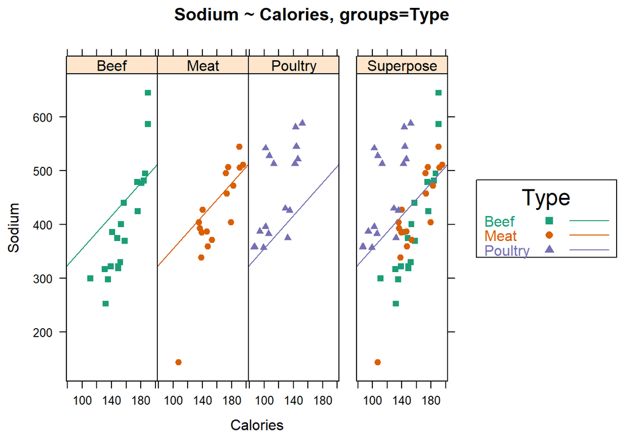

```r
CgT <- ancovaplot(Sodium ~ Calories, groups=Type, data=hotdog, col=col3x2,
                  main="Sodium ~ Calories, groups=Type",
                  scales=list(alternating=FALSE),
                  between=list(x=c(0,0,1)))
update(CgT, key=hotdog.key)
```

그룹변수를 Type으로 지정하고, 종속변수가 Sodium이고 독립변수가 Calories에 대한 `ancovaplot`을 그래프로 나타내보았다.

```r
aovStatementAndAnova(CgT, warn=FALSE)
```

```
## > anova(aov(Sodium ~ Calories, data = hotdog))
```

```
## Analysis of Variance Table
##
## Response: Sodium
##           Df Sum Sq Mean Sq F value    Pr(>F)
## Calories   1 106270  106270  14.515 0.0003693 ***
## Residuals 52 380718    7321
## ---
## Signif. codes:  0 '***' 0.001 '**' 0.01 '*' 0.05 '.' 0.1 ' ' 1
```

```r
anova(aov(Sodium ~ Calories, data=hotdog))
```

```
## Analysis of Variance Table
##
## Response: Sodium
##           Df Sum Sq Mean Sq F value    Pr(>F)
## Calories   1 106270  106270  14.515 0.0003693 ***
## Residuals 52 380718    7321
## ---
## Signif. codes:  0 '***' 0.001 '**' 0.01 '*' 0.05 '.' 0.1 ' ' 1
```

Type을 Group으로 지정하고 반응변수를 Sodium으로 했을 때, 유의확률이 유의수준 0.05보다 작으므로, Calories 변수에 따른 유의한 평균차이가 적어도 한 집단 이상 있는 것을 확인할 수 있다.

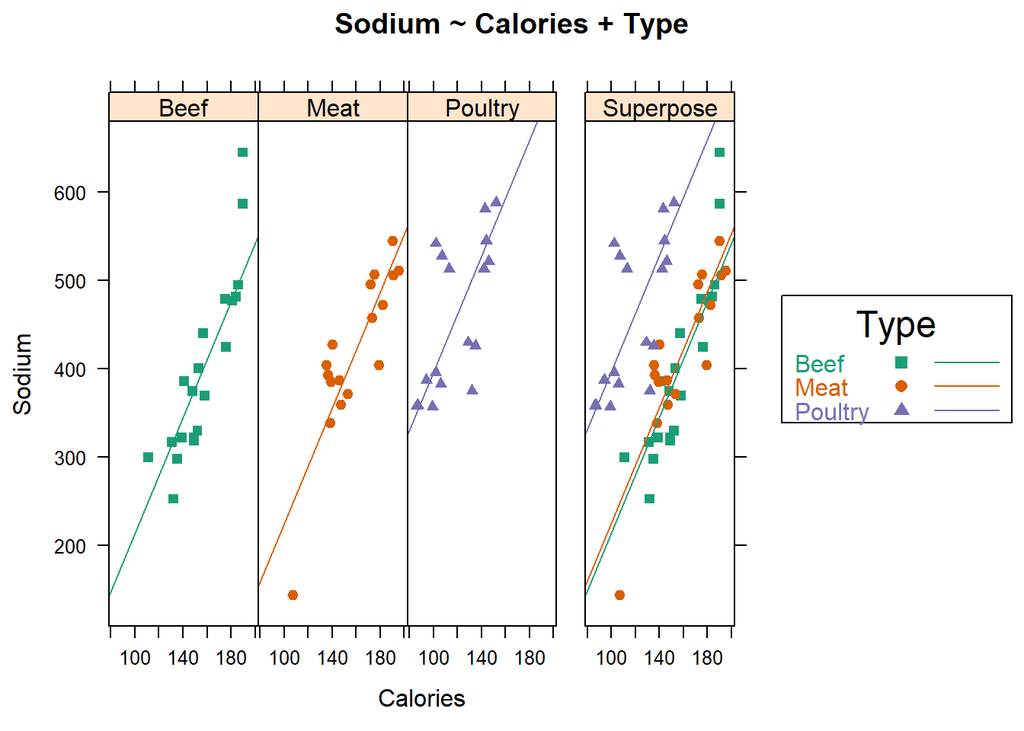

```r
hotdog.key <- list(title="Type", border=TRUE, space="right",
                   text=list(levels(hotdog$Type),
                             col=col3x2[1:3]),
                   points=list(pch=15:17,
                               col=col3x2[1:3]),
                   lines=list(lty=1,
                              lwd=trellis.par.get("superpose.line")$lwd[1:3],
                              col=col3x2[1:3]))
CpT <- ancovaplot(Sodium ~ Calories+Type, data=hotdog, col=col3x2,
                  main="Sodium ~ Calories + Type",
                  scales=list(alternating=FALSE),
                  between=list(x=c(0,0,1)))
update(CpT, key=hotdog.key)
```

종속변수를 Sodium으로하고 독립변수는 Calories, Type으로 지정한 후, `ancovaplot`을 그려 보았다.

```r
aovStatementAndAnova(CpT)
```

```
## > anova(aov(Sodium ~ Calories + Type, data = hotdog))
```

```
## Analysis of Variance Table
##
## Response: Sodium
##           Df Sum Sq Mean Sq F value    Pr(>F)
## Calories   1 106270  106270  34.654 3.281e-07 ***
## Type       2 227386  113693  37.074 1.336e-10 ***
## Residuals 50 153331    3067
## ---
## Signif. codes:  0 '***' 0.001 '**' 0.01 '*' 0.05 '.' 0.1 ' ' 1
```

```r
CpT.aov <- aov(Sodium ~ Calories + Type, data=hotdog)
anova(CpT.aov)
```

```
## Analysis of Variance Table
##
## Response: Sodium
##           Df Sum Sq Mean Sq F value    Pr(>F)
## Calories   1 106270  106270  34.654 3.281e-07 ***
## Type       2 227386  113693  37.074 1.336e-10 ***
## Residuals 50 153331    3067
## ---
## Signif. codes:  0 '***' 0.001 '**' 0.01 '*' 0.05 '.' 0.1 ' ' 1
```

분산분석결과, 종속변수 Sodium에 대해서 **Calories,Type**모두 유의한 것으로 보아 두 변수 모두 적어도 한 집단 간 유의한 평균차이가 존재한다는 것을 알 수 있다.

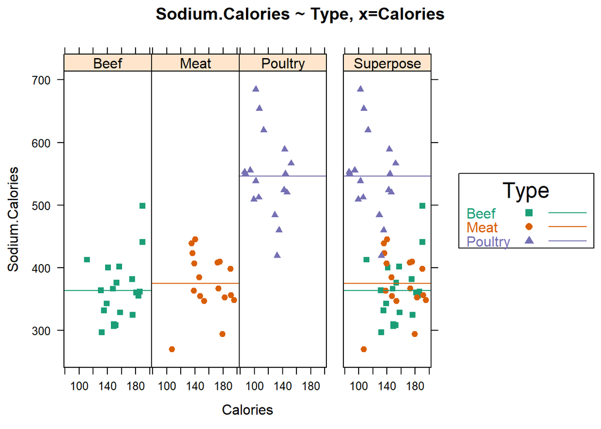

```r
hotdog.key <- list(title="Type", border=TRUE, space="right",
                   text=list(levels(hotdog$Type),
                             col=col3x2[1:3]),
                   points=list(pch=15:17,
                               col=col3x2[1:3]),
                   lines=list(lty=1,
                              lwd=trellis.par.get("superpose.line")$lwd[1:3],
                              col=col3x2[1:3]))

hotdog$Sodium.Calories <-
   hotdog$Sodium - predict.lm(CpT.aov, type="terms", terms="Calories")

T.C <- ancovaplot(Sodium.Calories ~ Type, x=Calories, data=hotdog, col=col3x2,
                  main="Sodium.Calories ~ Type, x=Calories",
                  scales=list(alternating=FALSE),
                  between=list(x=c(0,0,1)))
update(T.C, key=hotdog.key)
```

**hotdog$Sodium.Calories** 변수에 Sodium 변수 - (Calories + Type)을 이용한 회귀예측값을 계산하여 넣어주었다.  
그 다음, Sodium.Calories변수를 종속변수로 지정하고 Type을 독립변수로 지정한 후, Calories를 공변량으로 지정해주었다.

```r
aovStatementAndAnova(T.C)
```

```
## > anova(aov(Sodium.Calories ~ Type, data = hotdog))
```

```
## Analysis of Variance Table
##
## Response: Sodium.Calories
##           Df Sum Sq Mean Sq F value    Pr(>F)
## Type       2 368463  184232  61.278 2.737e-14 ***
## Residuals 51 153331    3006
## ---
## Signif. codes:  0 '***' 0.001 '**' 0.01 '*' 0.05 '.' 0.1 ' ' 1
```

```r
anova(aov(Sodium.Calories ~ Type, data=hotdog))
```

```
## Analysis of Variance Table
##
## Response: Sodium.Calories
##           Df Sum Sq Mean Sq F value    Pr(>F)
## Type       2 368463  184232  61.278 2.737e-14 ***
## Residuals 51 153331    3006
## ---
## Signif. codes:  0 '***' 0.001 '**' 0.01 '*' 0.05 '.' 0.1 ' ' 1
```

위의 Formula를 분산분석에 적용했을 때, Type 주효과는 유의한 것을 확인할 수 있다.  
따라서, Type 집단에 따라서 적어도 한 집단 간 유의한 평균 차이가 발생하는 것을 알 수 있다.

```r
CpT.mmc <- mmc(CpT.aov)
CpT.mmc
```

```
## Tukey contrasts
## Fit: aov(formula = Sodium ~ Calories + Type, data = hotdog)
## Estimated Quantile = 2.409789
## 95% family-wise confidence level
## $mca
##               estimate   stderr     lower     upper   height
## Poultry-Meat 171.46894 23.13185 115.72606 227.21182 460.7693
## Poultry-Beef 182.76147 22.18564 129.29877 236.22416 455.1230
## Meat-Beef     11.29252 18.27834 -32.75441  55.33945 369.3885
## $none
##         estimate   stderr    lower    upper   height
## Poultry 546.5037 16.06743 507.7846 585.2228 546.5037
## Meat    375.0348 14.12817 340.9889 409.0807 375.0348
## Beef    363.7423 12.94391 332.5502 394.9343 363.7423
```

차이가 발생하는 집단을 찾기 위해 다중비교를 진행하였다.  
**Poultry-Meat**, **Poultry-Beef**의 집단이 신뢰구간 0을 포함하지 않으므로 유의한 차이를 보이는 집단이라고 할 수 있다.

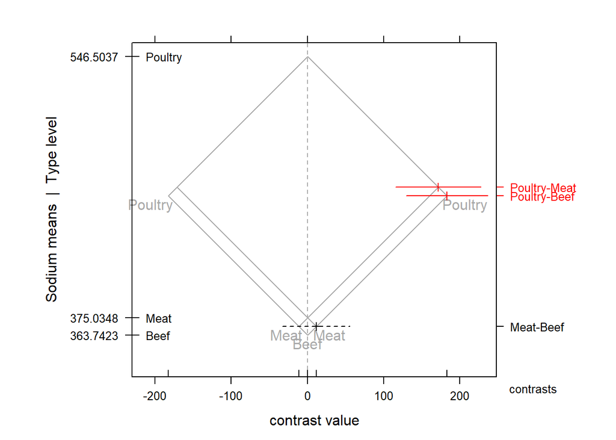

```r
mmcplot(CpT.mmc)
```

`mmcplot`을 통해서도 다중비교의 결과를 그림을 통해서 살펴볼 수 있다.

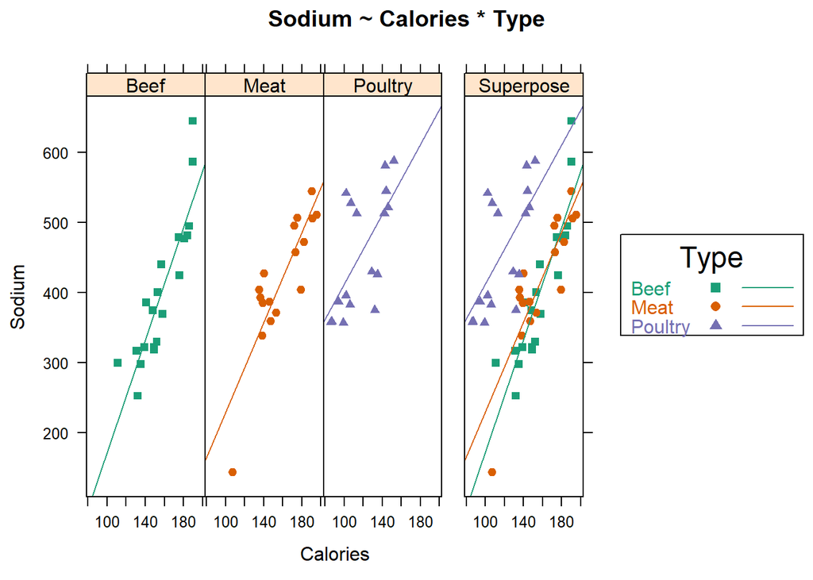

```r
CsT <- ancovaplot(Sodium ~ Calories * Type, data=hotdog, col=col3x2,
                  main="Sodium ~ Calories * Type",
                  scales=list(alternating=FALSE),
                  between=list(x=c(0,0,1)))
update(CsT, key=hotdog.key)
```

Sodium변수를 종속변수로 지정한 후, Calories,Type를 독립변수로 지정하였고 *를 이용하여 교호작용 또한 고려하여 `ancovaplot`을 통해 그림을 그려보았다.

```r
aovStatementAndAnova(CsT)
```

```
## > anova(aov(Sodium ~ Calories * Type, data = hotdog))
```

```
## Analysis of Variance Table
##
## Response: Sodium
##               Df Sum Sq Mean Sq F value    Pr(>F)
## Calories       1 106270  106270 35.6885 2.747e-07 ***
## Type           2 227386  113693 38.1815 1.195e-10 ***
## Calories:Type  2  10402    5201  1.7466    0.1853
## Residuals     48 142930    2978
## ---
## Signif. codes:  0 '***' 0.001 '**' 0.01 '*' 0.05 '.' 0.1 ' ' 1
```

```r
anova(aov(Sodium ~ Calories * Type,data=hotdog))
```

```
## Analysis of Variance Table
##
## Response: Sodium
##               Df Sum Sq Mean Sq F value    Pr(>F)
## Calories       1 106270  106270 35.6885 2.747e-07 ***
## Type           2 227386  113693 38.1815 1.195e-10 ***
## Calories:Type  2  10402    5201  1.7466    0.1853
## Residuals     48 142930    2978
## ---
## Signif. codes:  0 '***' 0.001 '**' 0.01 '*' 0.05 '.' 0.1 ' ' 1
```

분산분석 결과, 주효과들은 유의하다는 결과가 나왔지만, 두 주효과의 교호작용은 유의하지 않은 것을 확인할 수 있다.

### 10.6.5 Tests of Equality of Regression Lines

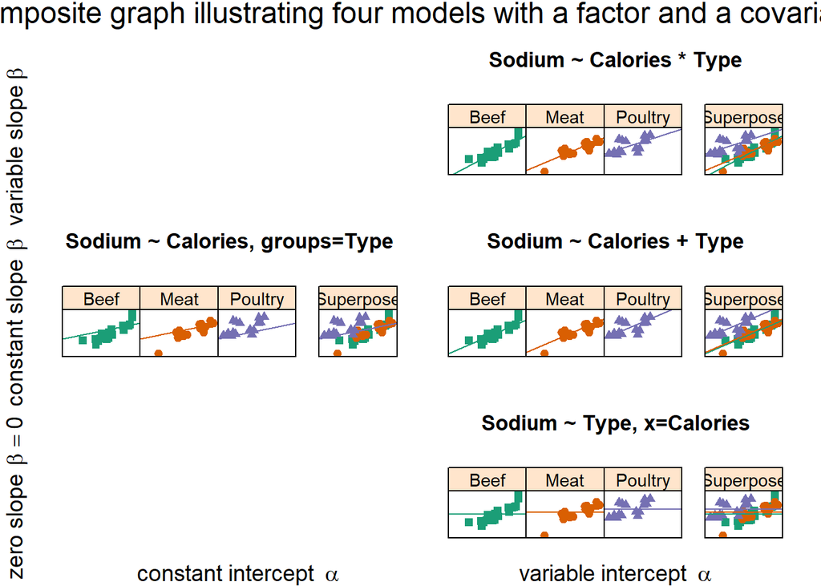

```r
removeAnnotation <-
       function(x) {
         update(x,
                main=list(x$main, cex=1.1),
                ylab=NULL,
                xlab=NULL,
                legend=NULL,
                scales=list(alternating=0, tck=0),
                par.strip.text=list(cex=.9, lines=1.1))
      }

## 2 x 3, with empty spots
print(position=c(.03, .31,  .53, .62), more=TRUE, removeAnnotation(CgT))
print(position=c(.50, .00, 1.00, .31), more=TRUE, removeAnnotation(TxC))
print(position=c(.50, .31, 1.00, .62), more=TRUE, removeAnnotation(CpT))
print(position=c(.50, .62, 1.00, .93), more=TRUE, removeAnnotation(CsT))

## column labeling
grid.text(x=c(.29, .75), y=.02, gp=gpar(fontsize=14),
          c(expression("constant intercept" ~~ alpha),
            expression("variable intercept" ~~ alpha)))

## row labeling
grid.text(x=.02, y=c(.15, .45, .75), rot=90, gp=gpar(fontsize=14),
          c(expression("zero slope" ~~ beta==0),
            expression("constant slope" ~~ beta),
            expression("variable slope" ~~ beta)))

## main title
grid.text(x=.5, y=.98, gp=gpar(fontsize=18),
          "Composite graph illustrating four models with a factor and a covariate")
```

## 10.7 ancovaplot Function

```r
data(hotdog,package = "HH")
data(col3x2,pacakge="HH")
```

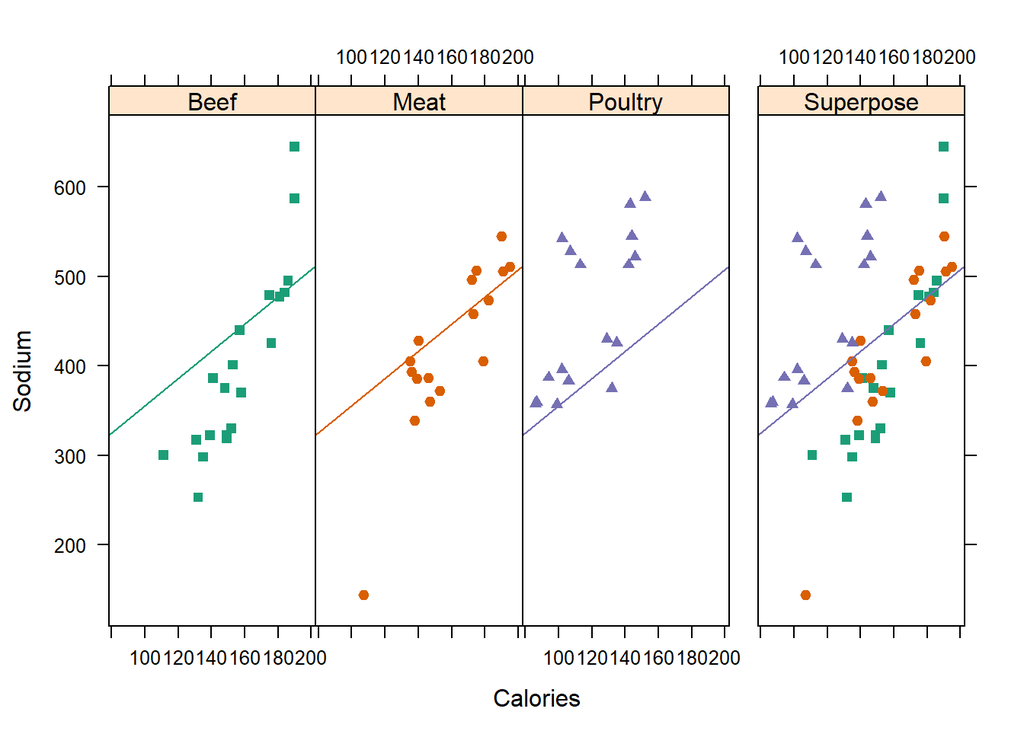

```r
## constant line across all groups
## y ~ x
ancovaplot(Sodium ~ Calories,groups=Type,data=hotdog,col=col3x2)
```

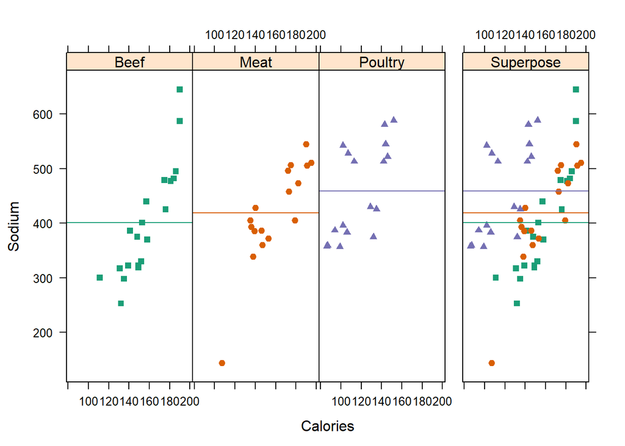

```r
## different horizontal line in each group
## y ~ a
ancovaplot(Sodium ~ Type, x = Calories, data=hotdog, col=col3x2)
```

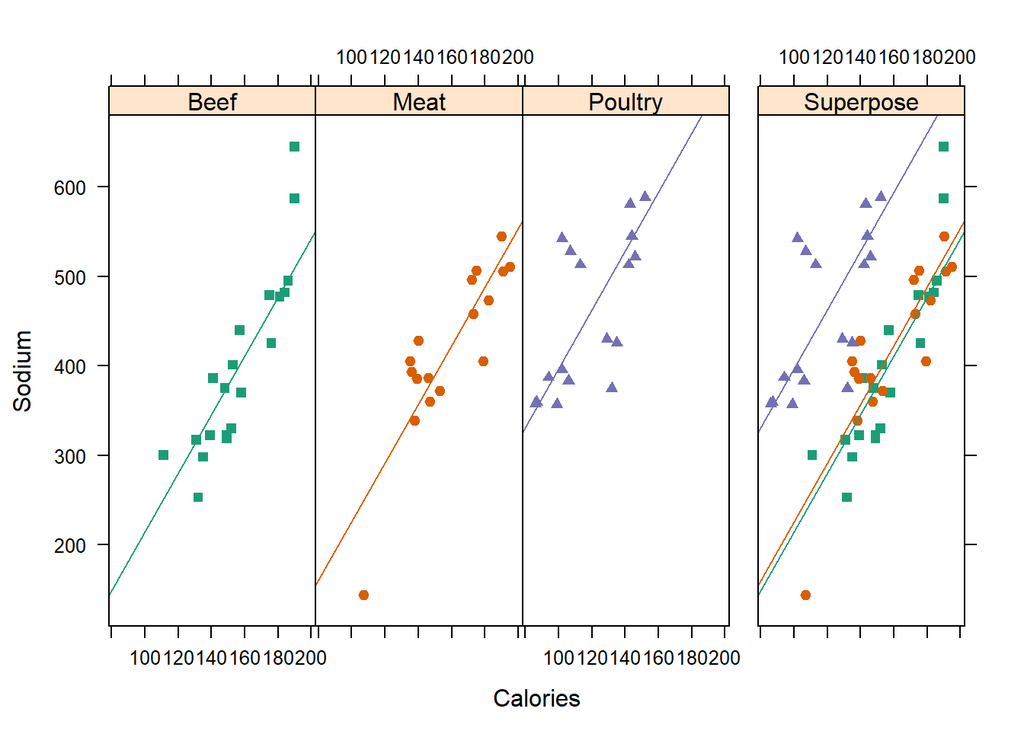

```r
## constant slope, different intercepts
## y ~ x + a or y ~ a + x
ancovaplot(Sodium ~ Calories + Type, data=hotdog, col=col3x2)
```

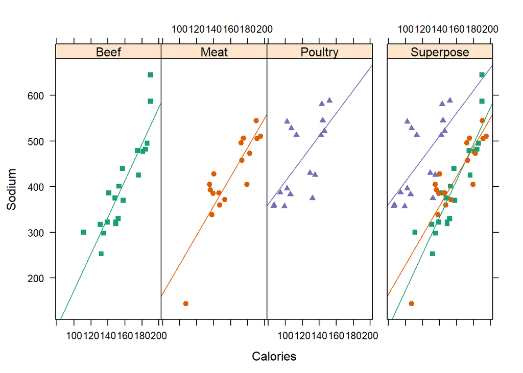

```r
## different slopes, and differnet intercepts
## y ~ x * a or y ~ a * x
ancovaplot(Sodium ~ Calories * Type, data=hotdog, col=col3x2)
```

`ancovaplot`또한 Formula를 +,* 등의 기호를 사용하여 다양한 조합을 그림으로 나타낼 수 있다.

# References

[ANCOVA](https://m.blog.naver.com/PostView.naver?isHttpsRedirect=true&blogId=y4769&logNo=220627663821)

# Summary of Chapter10

- **더미 변수(Dummy variable)**은 독립변수를 0과 1로 변환한 변수를 말한다. 예를 들어, 성별에 대한 데이터가 “M”,“F”인 경우, 문자열이기 때문에 데이터로 사용할 수가 없다. 따라서, 이러한 문자열에 대하여 숫자로 변환해주는 작업을 **더미변수변환**라고 할 수 있다.
- 문자열을 더미변수로 바꿔주는 과정에서 대응되는 더미를 잘못 만들어주거나, 원하는 가변수로 변하지 않은 상태에서 분석을 진행하면 이상한 모형이 도출될수도 있기 때문에 항상 더미변수화를 진행한 후에는 올바르게 변수변환이 되었는지 확인하는 것이 필요하다.
- 앞선 챕터에서 독립변수와 종속변수의 인과관계를 살펴보는 **회귀분석**과 종속변수에 대해서 독립변수의 집단 간 유의한 차이가 발생하는지에 대해 알아보기 위한 **분산분석**에 대해서 알아보았다.
- **공분산분석(ANCOVA)**는 회귀분석과 분산분석을 섞은 개념이라고 할 수 있다. 외생변수를 공변량으로 처리한 후, 독립변수의 각 집단 사이의 종속변수 값에 대해서 차이가 있는지를 확인하는 방법이다.
- **공변량**은 종속변수에 영향을 미칠 수 있으나 독립변수로 설정되지 않은 변수를 말하며, 잡음을 통제하는 과정이라고 말할 수 있다.
- 공분산분석 또한 분산분석, 회귀분석의 기본 가정사항인 **정규성**, **등분산성**, **독립성**을 가정한다.
- R에서 공분산분석을 진행하고자 하는 경우, `ancovaplot`을 이용하여 시각적인 방법을 이용하거나, `lm`함수를 이용하여 공변량을 지정하고 회귀모형을 적합시킨 후에, `anova`함수를 이용하여 분산분석을 진행함으로써 공분산분석의 결과를 얻을 수 있다.